<사용데이터 : [전국 사설 학원 수 단계 구분도 그리기 in R](https://2stndard.tistory.com/112) >

## 범주형 단계 구분도(Choropleth map)

[전국 사설 학원 수 단계 구분도 그리기 in R](https://2stndard.tistory.com/112)에서 그린 전국 사설학원수에 대한 단계 구분도는 단계를 구분하는 색이 연속형 변수로 색조의 변화와 변수가 매핑되어 있다. 하지만 그 지도에서도 보이듯이 서울, 경기 지역의 학원수가 타 시도에 비해 매우 크기 때문에 그 변화가 잘 눈에 띄지지 않는다. 따라서 이런 경우에는 연속형 변수를 범주형으로 바꾸어서 그 변수들의 단계가 명확히 보이도록 그리는게 좋을 것이다.

### cut()

`cut()`은 R base에서 제공하는 함수로 수치형 연속형 변수를 분할하여 범주형으로 만들어 주는 함수중에 하나로 가장 기본적인 함수이다. 따라서 R base에서 제공하는 `cut()`을 사용할 수 있고 이 함수에서 파생된 함수를 사용하는 방법이 있다. 여기서는 `ggplot2`에서 제공하는 `cut()` 파생 함수에 대해 알아본다.

#### R base의 cut()

`cut()`은 범주화하는데 필요한 분할점을 명기함으로써 그 분할점으로 범주를 나누는 함수이다. `cut()`을 사용하여 범주형 단계 구분도를 그리면 다음과 같다.

```r
df_joined <- df_joined |>
  mutate(level_cut_break = cut(학원수, breaks = c(-Inf, 1000, 3000, 5000, 7000, 9000, Inf),
                     labels = c('1,000개 미만', '1,000~2,999', '3,000~4,999', '5,000~6,999', '7,000~8,999', '9000개이상')
                      )
         )

as.data.frame(df_joined) |> select(시도, 학원수, level_cut_break) |> head()
```

```
##   시도 학원수 level_cut_break
## 1 강원   1987     1,000~2,999
## 2 경기  20381      9000개이상
## 3 경남   5546     5,000~6,999
## 4 경북   3257     3,000~4,999
## 5 광주   3009     3,000~4,999
## 6 대구   3508     3,000~4,999
```

```r
as.data.frame(df_joined) |> count(level_cut_break)
```

```
##   level_cut_break n
## 1    1,000개 미만 1
## 2     1,000~2,999 7
## 3     3,000~4,999 6
## 4     5,000~6,999 1
## 5      9000개이상 2
```

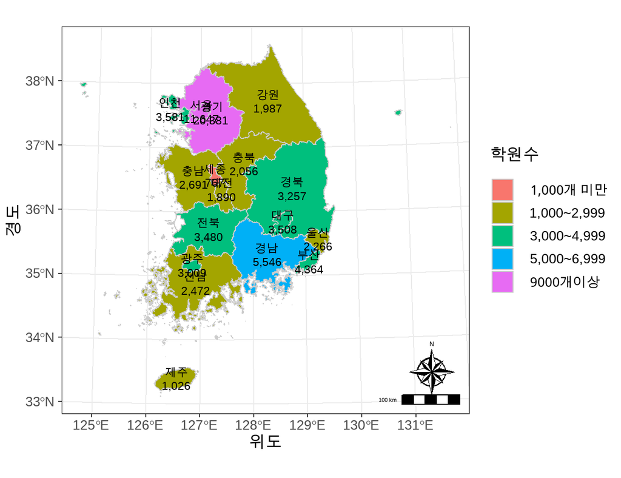

```r
df_joined |>
  ggplot() +
  geom_sf(aes(fill = level_cut_break), color = 'gray80') +
  geom_text(data = df_central, aes(x = X, y = Y, label = paste0(시도, '\n', scales::comma(학원수))), color = 'black', lineheight = 0.5, size = 6) +
  labs(x = '위도', y = '경도') +
  annotation_scale(location = "br") +
  annotation_north_arrow(location = "br", pad_y = unit(0.05, 'npc'),
                         style = north_arrow_nautical) +
  scale_fill_discrete(name = '학원수')
```

```r
df_joined <- df_joined |>
  mutate(level_cut_num = cut(학원수, breaks = 7, dig.lab = 5)
         )

as.data.frame(df_joined) |> select(시도, 학원수, level_cut_num) |> head()
```

```
##   시도 학원수 level_cut_num
## 1 강원   1987 (747.39,3569]
## 2 경기  20381 (17579,20401]
## 3 경남   5546   (3569,6371]
## 4 경북   3257 (747.39,3569]
## 5 광주   3009 (747.39,3569]
## 6 대구   3508 (747.39,3569]
```

```r
as.data.frame(df_joined) |> count(level_cut_num)
```

```
##   level_cut_num  n
## 1 (747.39,3569] 12
## 2   (3569,6371]  3
## 3  (9173,11975]  1
## 4 (17579,20401]  1
```

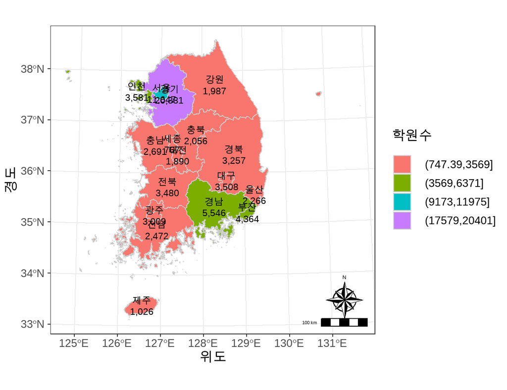

```r
df_joined |>
  ggplot() +
  geom_sf(aes(fill = level_cut_num), color = 'gray80') +
  geom_text(data = df_central, aes(x = X, y = Y, label = paste0(시도, '\n', scales::comma(학원수))), color = 'black', lineheight = 0.5, size = 6) +
  labs(x = '위도', y = '경도') +
  annotation_scale(location = "br") +
  annotation_north_arrow(location = "br", pad_y = unit(0.05, 'npc'),
                         style = north_arrow_nautical) +
  scale_fill_discrete(name = '학원수')
```

#### ggplot2의 cut_*()

보통 `ggplot2`패키지는 시각화에 전용으로 사용되는 패키지로 알고 있다. 하지만 `ggplot2`에도 데이터 전처리를 위한 일부 함수가 제공되고 있다는 것이다. 물론 이 함수들도 시각화에 사용되기 위해 설계된 함수이지만 일반적인 데이터 전처리에도 사용될 수 있다. 여기서 다루고자 하는 `cut_*()`도 `ggplot2` 패키지에서 제공되는 함수이다.

이 함수들은 `cut()`을 기본으로 설계되었기 때문에 `cut()`에서 사용하는 매개변수를 사용할 수 있다.

```r
df_joined <- df_joined |>
  mutate(level_cut_cut_interval = cut_interval(학원수, 7, dig.lab = 5)
         )

as.data.frame(df_joined) |> select(시도, 학원수, level_cut_cut_interval) |> head()
```

```
##   시도 학원수 level_cut_cut_interval
## 1 강원   1987             [767,3569]
## 2 경기  20381          (17579,20381]
## 3 경남   5546            (3569,6371]
## 4 경북   3257             [767,3569]
## 5 광주   3009             [767,3569]
## 6 대구   3508             [767,3569]
```

```r
as.data.frame(df_joined) |> count(level_cut_cut_interval)
```

```
##   level_cut_cut_interval  n
## 1             [767,3569] 12
## 2            (3569,6371]  3
## 3           (9173,11975]  1
## 4          (17579,20381]  1
```

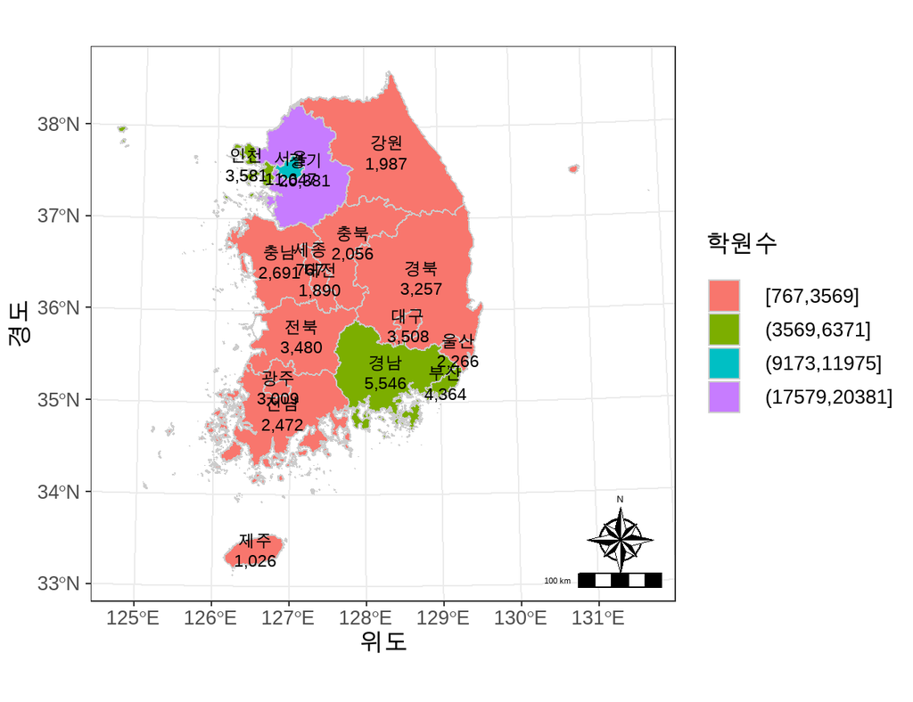

```r
df_joined |>
  ggplot() +
  geom_sf(aes(fill = level_cut_cut_interval), color = 'gray80') +
  geom_text(data = df_central, aes(x = X, y = Y, label = paste0(시도, '\n', scales::comma(학원수))), color = 'black', lineheight = 0.5, size = 6) +
  labs(x = '위도', y = '경도') +
  annotation_scale(location = "br") +
  annotation_north_arrow(location = "br", pad_y = unit(0.05, 'npc'),
                         style = north_arrow_nautical) +
  scale_fill_discrete(name = '학원수')
```

```r
df_joined <- df_joined |>
  mutate(level_cut_cut_width = cut_width(학원수, 2000, center = TRUE, dig.lab = 5)
         )

as.data.frame(df_joined) |> select(시도, 학원수, level_cut_cut_width) |> head()
```

```
##   시도 학원수 level_cut_cut_width
## 1 강원   1987         (1001,3001]
## 2 경기  20381       (19001,21001]
## 3 경남   5546         (5001,7001]
## 4 경북   3257         (3001,5001]
## 5 광주   3009         (3001,5001]
## 6 대구   3508         (3001,5001]
```

```r
as.data.frame(df_joined) |> count(level_cut_cut_width)
```

```
##   level_cut_cut_width n
## 1         [-999,1001] 1
## 2         (1001,3001] 7
## 3         (3001,5001] 6
## 4         (5001,7001] 1
## 5       (11001,13001] 1
## 6       (19001,21001] 1
```

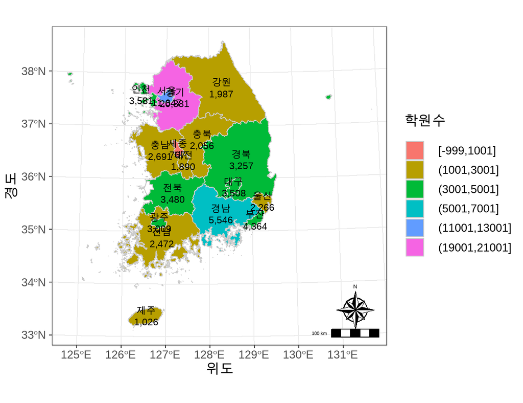

```r
df_joined |>
  ggplot() +
  geom_sf(aes(fill = level_cut_cut_width), color = 'gray80') +
  geom_text(data = df_central, aes(x = X, y = Y, label = paste0(시도, '\n', scales::comma(학원수))), color = 'black', lineheight = 0.5, size = 6) +
  labs(x = '위도', y = '경도') +
  annotation_scale(location = "br") +
  annotation_north_arrow(location = "br", pad_y = unit(0.05, 'npc'),
                         style = north_arrow_nautical) +
  scale_fill_discrete(name = '학원수')
```

### discretize()

```r
if(!require(arules)) {
  install.packages(arules)
  library(arules)
}

df_joined <- df_joined |>
  mutate(level_discretize_freq = discretize(학원수, breaks = 7)
         )

as.data.frame(df_joined) |> select(시도, 학원수, level_discretize_freq) |> head()
```

```
##   시도 학원수 level_discretize_freq
## 1 강원   1987   [1.92e+03,2.18e+03)
## 2 경기  20381   [5.21e+03,2.04e+04]
## 3 경남   5546   [5.21e+03,2.04e+04]
## 4 경북   3257   [2.66e+03,3.29e+03)
## 5 광주   3009   [2.66e+03,3.29e+03)
## 6 대구   3508   [3.29e+03,3.54e+03)
```

```r
as.data.frame(df_joined) |> count(level_discretize_freq)
```

```
##   level_discretize_freq n
## 1        [767,1.92e+03) 3
## 2   [1.92e+03,2.18e+03) 2
## 3   [2.18e+03,2.66e+03) 2
## 4   [2.66e+03,3.29e+03) 3
## 5   [3.29e+03,3.54e+03) 2
## 6   [3.54e+03,5.21e+03) 2
## 7   [5.21e+03,2.04e+04] 3
```

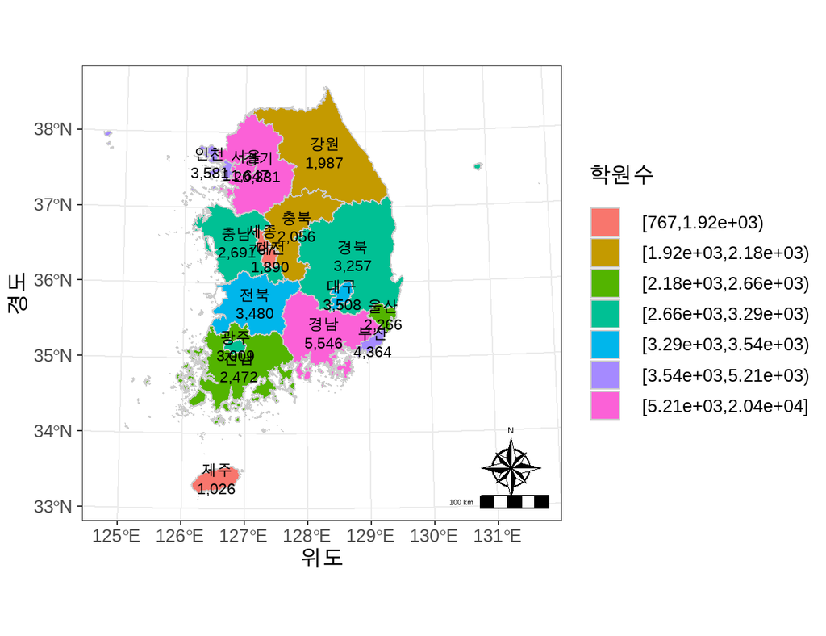

```r
df_joined |>
  ggplot() +
  geom_sf(aes(fill = level_discretize_freq), color = 'gray80') +
  geom_text(data = df_central, aes(x = X, y = Y, label = paste0(시도, '\n', scales::comma(학원수))), color = 'black', lineheight = 0.5, size = 6) +
  labs(x = '위도', y = '경도') +
  annotation_scale(location = "br") +
  annotation_north_arrow(location = "br", pad_y = unit(0.05, 'npc'),
                         style = north_arrow_nautical) +
  scale_fill_discrete(name = '학원수')
```

위의 결과를 보면 `cut()`의 `break`에 범주의 수로 그룹화하는것과 `discretize()`로 그룹화하는것의 결과가 차이가 있다. 이는 `discretize()`의 범주화에 사용하는 방식의 차이이다. `cut()`은 값의 최대값과 최소값을 기준으로 등간격의 범주로 나누는 반면 `discretize()`에서는 범주를 나누는 방식을 ‘interval’(등간격), ‘frequency’(등분포), ‘cluster’(k-means 클러스터링), ‘fixed’(breaks에 명기된 분할점)의 네 가지 방법을 사용하는데 기본적으로 ’frequency’를 사용하기 때문에 각각의 범주에 배치되는 사례수가 최대한 같게 범주를 나눈다. 만약 K-means 클러스터링을 사용하여 범주화한다면 다음과 같이 결과가 나온다.

```r
df_joined <- df_joined |>
  mutate(level_discretize_cluster = discretize(학원수, method ='cluster', breaks = 7)
         )

as.data.frame(df_joined) |> select(시도, 학원수, level_discretize_cluster) |> head()
```

```
##   시도 학원수 level_discretize_cluster
## 1 강원   1987      [1.47e+03,2.39e+03)
## 2 경기  20381       [1.6e+04,2.04e+04]
## 3 경남   5546       [4.59e+03,8.6e+03)
## 4 경북   3257      [3.18e+03,4.59e+03)
## 5 광주   3009      [2.39e+03,3.18e+03)
## 6 대구   3508      [3.18e+03,4.59e+03)
```

```r
as.data.frame(df_joined) |> count(level_discretize_cluster)
```

```
##   level_discretize_cluster n
## 1           [767,1.47e+03) 2
## 2      [1.47e+03,2.39e+03) 4
## 3      [2.39e+03,3.18e+03) 3
## 4      [3.18e+03,4.59e+03) 5
## 5       [4.59e+03,8.6e+03) 1
## 6        [8.6e+03,1.6e+04) 1
## 7       [1.6e+04,2.04e+04] 1
```

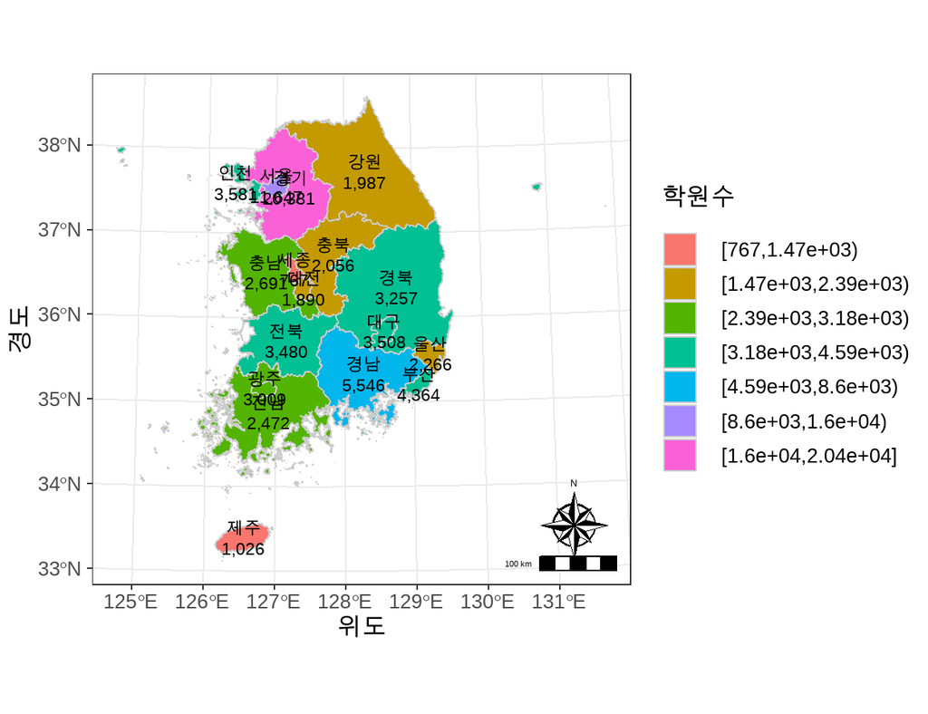

```r
df_joined |>
  ggplot() +
  geom_sf(aes(fill = level_discretize_cluster), color = 'gray80') +
  geom_text(data = df_central, aes(x = X, y = Y, label = paste0(시도, '\n', scales::comma(학원수))), color = 'black', lineheight = 0.5, size = 6) +
  labs(x = '위도', y = '경도') +
  annotation_scale(location = "br") +
  annotation_north_arrow(location = "br", pad_y = unit(0.05, 'npc'),
                         style = north_arrow_nautical) +
  scale_fill_discrete(name = '학원수')
```

다만 `discretize()`에도 `cut()`에서 사용했던 `dig.lag`을 사용하여 표현되는 수치의 포맷을 설정할 수 있다고 매뉴얼에 기재되어 있지만 소스코드를 확인해도 이는 작동하지 않는 듯하다. 아마도 오류이지 않을까 싶다.

지금까지 각각의 함수를 사용하여 나눈 범주들을 비교하면 다음과 같다.

| 시도 | 학원수 | level_cut_break | level_cut_num | level_cut_cut_interval | level_cut_cut_width | level_discretize_freq | level_discretize_cluster |
| --- | --- | --- | --- | --- | --- | --- | --- |
| 강원 | 1987 | 1,000~2,999 | (747.39,3569] | [767,3569] | (1001,3001] | [1.92e+03,2.18e+03) | [1.47e+03,2.39e+03) |
| 경기 | 20381 | 9000개이상 | (17579,20401] | (17579,20381] | (19001,21001] | [5.21e+03,2.04e+04] | [1.6e+04,2.04e+04] |
| 경남 | 5546 | 5,000~6,999 | (3569,6371] | (3569,6371] | (5001,7001] | [5.21e+03,2.04e+04] | [4.59e+03,8.6e+03) |
| 경북 | 3257 | 3,000~4,999 | (747.39,3569] | [767,3569] | (3001,5001] | [2.66e+03,3.29e+03) | [3.18e+03,4.59e+03) |
| 광주 | 3009 | 3,000~4,999 | (747.39,3569] | [767,3569] | (3001,5001] | [2.66e+03,3.29e+03) | [2.39e+03,3.18e+03) |
| 대구 | 3508 | 3,000~4,999 | (747.39,3569] | [767,3569] | (3001,5001] | [3.29e+03,3.54e+03) | [3.18e+03,4.59e+03) |
| 대전 | 1890 | 1,000~2,999 | (747.39,3569] | [767,3569] | (1001,3001] | [767,1.92e+03) | [1.47e+03,2.39e+03) |
| 부산 | 4364 | 3,000~4,999 | (3569,6371] | (3569,6371] | (3001,5001] | [3.54e+03,5.21e+03) | [3.18e+03,4.59e+03) |
| 서울 | 11647 | 9000개이상 | (9173,11975] | (9173,11975] | (11001,13001] | [5.21e+03,2.04e+04] | [8.6e+03,1.6e+04) |
| 세종 | 767 | 1,000개 미만 | (747.39,3569] | [767,3569] | [-999,1001] | [767,1.92e+03) | [767,1.47e+03) |
| 울산 | 2266 | 1,000~2,999 | (747.39,3569] | [767,3569] | (1001,3001] | [2.18e+03,2.66e+03) | [1.47e+03,2.39e+03) |
| 인천 | 3581 | 3,000~4,999 | (3569,6371] | (3569,6371] | (3001,5001] | [3.54e+03,5.21e+03) | [3.18e+03,4.59e+03) |
| 전남 | 2472 | 1,000~2,999 | (747.39,3569] | [767,3569] | (1001,3001] | [2.18e+03,2.66e+03) | [2.39e+03,3.18e+03) |
| 전북 | 3480 | 3,000~4,999 | (747.39,3569] | [767,3569] | (3001,5001] | [3.29e+03,3.54e+03) | [3.18e+03,4.59e+03) |
| 제주 | 1026 | 1,000~2,999 | (747.39,3569] | [767,3569] | (1001,3001] | [767,1.92e+03) | [767,1.47e+03) |
| 충남 | 2691 | 1,000~2,999 | (747.39,3569] | [767,3569] | (1001,3001] | [2.66e+03,3.29e+03) | [2.39e+03,3.18e+03) |
| 충북 | 2056 | 1,000~2,999 | (747.39,3569] | [767,3569] | (1001,3001] | [1.92e+03,2.18e+03) | [1.47e+03,2.39e+03) |